# Part 1: Programming Solution

## Task 1: Loan Data Automation

Loading Data from Different File Formats:

Excel Files:

- To import data from Excel files, the pandas library provides a simple function, `pd.read_excel('file_path.xlsx')`

PDF Files:

- While pandas doesn't have a built-in function for PDFs, there's a reliable solution: the **tabula-py** library, specifically designed for extracting tabular data from PDFs. A community [thread](https://stackoverflow.com/questions/23284759/opening-a-pdf-and-reading-in-tables-with-python-pandas) on Stack Overflow recommends this tool

Learn more about tabula-py here: https://pypi.org/project/tabula-py/

```python
# First we install tabula using pip
!pip install tabula-py
```

### Importing necessary libraries

```python
import numpy as np
import pandas as pd
import matplotlib.pyplot as plt
import seaborn as sns
import tabula
import math
```

### Loading in the Excel file

```python
# loading the excel file using pandas method .read_excel
loans_xlsx = pd.read_excel("/content/drive/MyDrive/AFS/APEX Loan Data.xlsx")
loans_xlsx.head()
```

|  | Loan_ID | Gender | Married | Dependents | Graduate | Self_Employed | ApplicantIncome | CoapplicantIncome | LoanAmount | Loan_Amount_Term | Credit_History | Property_Area | Loan_Status |
| --- | --- | --- | --- | --- | --- | --- | --- | --- | --- | --- | --- | --- | --- |
| 0 | 2284 | 1 | 0 | 0 | 0 | 0 | 3902 | 1666.0 | 109 | 333 | 1 | 3 | Y |
| 1 | 2287 | 2 | 0 | 0 | 1 | 0 | 1500 | 1800.0 | 103 | 333 | 0 | 2 | N |
| 2 | 2288 | 1 | 1 | 2 | 0 | 0 | 2889 | 0.0 | 45 | 180 | 0 | 1 | N |
| 3 | 2296 | 1 | 0 | 0 | 0 | 0 | 2755 | 0.0 | 65 | 300 | 1 | 3 | N |
| 4 | 2297 | 1 | 0 | 0 | 1 | 0 | 2500 | 20000.0 | 103 | 333 | 1 | 2 | Y |

```python
# checking the datatypes of the dataframe
loans_xlsx.info()
```

```
<class 'pandas.core.frame.DataFrame'>
RangeIndex: 247 entries, 0 to 246
Data columns (total 13 columns):
 #   Column             Non-Null Count  Dtype
---  ------             --------------  -----
 0   Loan_ID            247 non-null    int64
 1   Gender             247 non-null    int64
 2   Married            247 non-null    int64
 3   Dependents         247 non-null    int64
 4   Graduate           247 non-null    int64
 5   Self_Employed      247 non-null    int64
 6   ApplicantIncome    247 non-null    int64
 7   CoapplicantIncome  247 non-null    float64
 8   LoanAmount         247 non-null    int64
 9   Loan_Amount_Term   247 non-null    int64
 10  Credit_History     247 non-null    int64
 11  Property_Area      247 non-null    int64
 12  Loan_Status        247 non-null    object
dtypes: float64(1), int64(11), object(1)
memory usage: 25.2+ KB
```

```python
# Converting `CoapplicantIncome` to a integer data type
loans_xlsx['CoapplicantIncome'] = loans_xlsx['CoapplicantIncome'].astype(int)
```

```python
# Confirming changes
loans_xlsx.info()
```

```
<class 'pandas.core.frame.DataFrame'>
RangeIndex: 247 entries, 0 to 246
Data columns (total 13 columns):
 #   Column             Non-Null Count  Dtype
---  ------             --------------  -----
 0   Loan_ID            247 non-null    int64
 1   Gender             247 non-null    int64
 2   Married            247 non-null    int64
 3   Dependents         247 non-null    int64
 4   Graduate           247 non-null    int64
 5   Self_Employed      247 non-null    int64
 6   ApplicantIncome    247 non-null    int64
 7   CoapplicantIncome  247 non-null    int64
 8   LoanAmount         247 non-null    int64
 9   Loan_Amount_Term   247 non-null    int64
 10  Credit_History     247 non-null    int64
 11  Property_Area      247 non-null    int64
 12  Loan_Status        247 non-null    object
dtypes: int64(12), object(1)
memory usage: 25.2+ KB
```

### Loading in the PDF tables

```python
# loading the pdf tables using tabula-py
loans_df_list = tabula.read_pdf("/content/drive/MyDrive/AFS/APEX_Loans_Database_Table.pdf", pages='all')
```

```python
# Tabula loads all the tables in the pdf file as a list of dataframes
# printing the type and number of objects in the loans_df_list list
print(len(loans_df_list))
print(type(loans_df_list))
```

```
14
<class 'list'>
```

The number of tables in the list (14) matches the number of pages in the original PDF

#### Cleaning PDF dataframes

```python
# Checking the first dataframe in the list
loans_df_list[0].head()
```

|  | Loan_ID | Gender | Married | Dependents | Graduate | Self_Employed | ApplicantIncome | CoapplicantIncome | LoanAmount | Loan_Amount_Term | Credit_History | Property_Area | Loan_Status |
| --- | --- | --- | --- | --- | --- | --- | --- | --- | --- | --- | --- | --- | --- |
| 0 | 1002 | 1 | 0 | 0 | 1 | 0 | 5849 | 0 | 128 | 360 | 1 | 1 | Y |
| 1 | 1003 | 1 | 1 | 1 | 1 | 0 | 4583 | 1508 | 128 | 360 | 1 | 3 | N |
| 2 | 1005 | 1 | 1 | 0 | 1 | 1 | 3000 | 0 | 66 | 360 | 1 | 1 | Y |
| 3 | 1006 | 1 | 1 | 0 | 0 | 0 | 2583 | 2358 | 120 | 360 | 1 | 1 | Y |
| 4 | 1008 | 1 | 0 | 0 | 1 | 0 | 6000 | 0 | 141 | 360 | 1 | 1 | Y |

```python
# Checking the second dataframe in the list
loans_df_list[1].head()
```

|  | 1086 | 1 | 0 | 0.1 | 0.2 | 0.3 | 1442 | 0.4 | 35 | 360 | 1.1 | 1.2 | N |
| --- | --- | --- | --- | --- | --- | --- | --- | --- | --- | --- | --- | --- | --- |
| 0 | 1087 | 2 | 0 | 2 | 1 | 0 | 3750 | 2083 | 120 | 360 | 1 | 2 | Y |
| 1 | 1091 | 1 | 1 | 1 | 1 | 0 | 4166 | 3369 | 201 | 360 | 0 | 1 | N |
| 2 | 1095 | 1 | 0 | 0 | 1 | 0 | 3167 | 0 | 74 | 360 | 1 | 1 | N |
| 3 | 1097 | 1 | 0 | 1 | 1 | 1 | 4692 | 0 | 106 | 360 | 1 | 3 | N |
| 4 | 1098 | 1 | 1 | 0 | 1 | 0 | 3500 | 1667 | 114 | 360 | 1 | 2 | Y |

**Issue:**

- The first dataframe has correct column headers, but later dataframes mistakenly use the first data row as headers.
- This prevents direct concatenation using `pd.concat` due to mismatched headers.

**Solution:**

1. **Isolate Correct Header DataFrame:**
   - Create an empty list, `processed_dfs`, to store corrected dataframes.
   - Add the first dataframe (with correct headers) to `processed_dfs` as it is.
2. **Fix Remaining DataFrames:**
   - Iterate through the rest of the dataframes:
     - **Extract Misplaced Headers:** Create a new dataframe using the first row (which contains misplaced headers) as its first data row.
     - **Add Correct Headers:** Assign appropriate column headers from the first dataframe to this new dataframe.
     - **Concatenate with Corrected Data:** Combine this header-fixed dataframe with the remaining rows of the original dataframe using `dataframe_list[i].iloc[1:]`.
     - **Rename Columns:** Apply the correct headers from the first dataframe to ensure consistency.
     - **Append to Processed DataFrames:** Add the corrected dataframe to the `processed_dfs` list.
3. **Concatenate Corrected DataFrames:**
   - Merge all dataframes in `processed_dfs` using `pd.concat` without header-related errors, as they now share a consistent header structure.

```python
# function to resolve the issue
def concatenate_pdfs(dataframe_list):
  """Concatenates a list of DataFrames, handling potential header inconsistencies.

  This function addresses cases where initial DataFrames may have incorrect
  headers (e.g., using the first data row as headers). It ensures consistent
  headers before concatenation.

  Args:
    dataframe_list: A list of DataFrames to be concatenated.

  Returns:
    A single DataFrame containing the concatenated data, with consistent headers.

  Raises:
    ValueError: If the number of column headers and new names provided for renaming
               are not equal.
  """
  # Create an empty list to store the processed DataFrames
  processed_dfs = []

  # Process the first DataFrame as-is
  processed_dfs.append(dataframe_list[0])

  # Process the remaining DataFrames
  for i in range(1, len(dataframe_list)):
      # Extract column headers and create desired names
      column_headers = dataframe_list[i].columns
      new_column_names = dataframe_list[0].columns.to_list()  # Replace with your desired names

      # Check if the number of headers and new names match
      if len(column_headers) != len(new_column_names):
          raise ValueError("Number of column headers and new names must be equal")

      # Create a new DataFrame with headers as the first row
      new_df = pd.DataFrame([column_headers], columns=column_headers)

      # Insert the new row and rename columns
      processed_df = pd.concat([new_df, dataframe_list[i].iloc[1:]], ignore_index=True).rename(columns=dict(zip(column_headers, new_column_names)))
      processed_dfs.append(processed_df)


  # Concatenate the processed DataFrames into a single DataFrame
  loans_df = pd.concat(processed_dfs, ignore_index=True)
  return loans_df
```

```python
# Running the function
loans_pdf = concatenate_pdfs(loans_df_list)
```

```python
# checking the datatypes of the combined dataframe
loans_pdf.info()
```

```
<class 'pandas.core.frame.DataFrame'>
RangeIndex: 385 entries, 0 to 384
Data columns (total 13 columns):
 #   Column             Non-Null Count  Dtype
---  ------             --------------  -----
 0   Loan_ID            385 non-null    object
 1   Gender             385 non-null    object
 2   Married            385 non-null    object
 3   Dependents         385 non-null    object
 4   Graduate           385 non-null    object
 5   Self_Employed      385 non-null    object
 6   ApplicantIncome    385 non-null    object
 7   CoapplicantIncome  385 non-null    object
 8   LoanAmount         385 non-null    object
 9   Loan_Amount_Term   385 non-null    object
 10  Credit_History     385 non-null    object
 11  Property_Area      385 non-null    object
 12  Loan_Status        385 non-null    object
dtypes: object(13)
memory usage: 39.2+ KB
```

While `loans_pdf.info()` output shows all columns as 'object', we expect some to be numeric. We should convert these columns to appropriate numeric data types.

```python
# Viewing a section of the dataframe such that we see rows that were at the end and beginning of the tables in the pdf
loans_pdf.loc[27:70]
```

|  | Loan_ID | Gender | Married | Dependents | Graduate | Self_Employed | ApplicantIncome | CoapplicantIncome | LoanAmount | Loan_Amount_Term | Credit_History | Property_Area | Loan_Status |
| --- | --- | --- | --- | --- | --- | --- | --- | --- | --- | --- | --- | --- | --- |
| 27 | 1073 | 1 | 1 | 2 | 0 | 0 | 4226 | 1040 | 110 | 360 | 1 | 1 | Y |
| 28 | 1086 | 1 | 0 | 0.1 | 0.2 | 0.3 | 1442 | 0.4 | 35 | 360 | 1.1 | 1.2 | N |
| 29 | 1091 | 1 | 1 | 1 | 1 | 0 | 4166 | 3369 | 201 | 360 | 0 | 1 | N |
| 30 | 1095 | 1 | 0 | 0 | 1 | 0 | 3167 | 0 | 74 | 360 | 1 | 1 | N |
| 31 | 1097 | 1 | 0 | 1 | 1 | 1 | 4692 | 0 | 106 | 360 | 1 | 3 | N |
| 32 | 1098 | 1 | 1 | 0 | 1 | 0 | 3500 | 1667 | 114 | 360 | 1 | 2 | Y |
| 33 | 1100 | 1 | 0 | 3 | 1 | 0 | 12500 | 3000 | 320 | 360 | 1 | 3 | N |
| 34 | 1106 | 1 | 1 | 0 | 1 | 0 | 2275 | 2067 | 128 | 360 | 1 | 1 | Y |
| 35 | 1109 | 1 | 1 | 0 | 1 | 0 | 1828 | 1330 | 100 | 360 | 0 | 1 | N |
| 36 | 1112 | 2 | 1 | 0 | 1 | 0 | 3667 | 1459 | 144 | 360 | 1 | 2 | Y |
| 37 | 1114 | 1 | 0 | 0 | 1 | 0 | 4166 | 7210 | 184 | 360 | 1 | 1 | Y |
| 38 | 1116 | 1 | 0 | 0 | 0 | 0 | 3748 | 1668 | 110 | 360 | 1 | 2 | Y |
| 39 | 1119 | 1 | 0 | 0 | 1 | 0 | 3600 | 0 | 80 | 360 | 1 | 1 | N |
| 40 | 1120 | 1 | 0 | 0 | 1 | 0 | 1800 | 1213 | 47 | 360 | 1 | 1 | Y |
| 41 | 1123 | 1 | 1 | 0 | 1 | 0 | 2400 | 0 | 75 | 360 | 0 | 1 | Y |
| 42 | 1131 | 1 | 1 | 0 | 1 | 0 | 3941 | 2336 | 134 | 360 | 1 | 2 | Y |
| 43 | 1136 | 1 | 1 | 0 | 0 | 1 | 4695 | 0 | 96 | 360 | 1 | 1 | Y |
| 44 | 1137 | 2 | 0 | 0 | 1 | 0 | 3410 | 0 | 88 | 360 | 1 | 1 | Y |
| 45 | 1138 | 1 | 1 | 1 | 1 | 0 | 5649 | 0 | 44 | 360 | 1 | 1 | Y |
| 46 | 1144 | 1 | 1 | 0 | 1 | 0 | 5821 | 0 | 144 | 360 | 1 | 1 | Y |
| 47 | 1146 | 2 | 1 | 0 | 1 | 0 | 2645 | 3440 | 120 | 360 | 0 | 1 | N |
| 48 | 1151 | 2 | 0 | 0 | 1 | 0 | 4000 | 2275 | 144 | 360 | 1 | 2 | Y |
| 49 | 1155 | 2 | 1 | 0 | 0 | 0 | 1928 | 1644 | 100 | 360 | 1 | 2 | Y |
| 50 | 1157 | 2 | 0 | 0 | 1 | 0 | 3086 | 0 | 120 | 360 | 1 | 2 | Y |
| 51 | 1164 | 2 | 0 | 0 | 1 | 0 | 4230 | 0 | 112 | 360 | 1 | 2 | N |
| 52 | 1179 | 1 | 1 | 2 | 1 | 0 | 4616 | 0 | 134 | 360 | 1 | 1 | N |
| 53 | 1186 | 2 | 1 | 1 | 1 | 1 | 11500 | 0 | 286 | 360 | 0 | 1 | N |
| 54 | 1194 | 1 | 1 | 2 | 1 | 0 | 2708 | 1167 | 97 | 360 | 1 | 2 | Y |
| 55 | 1195 | 1 | 1 | 0 | 1 | 0 | 2132 | 1591 | 96 | 360 | 1 | 2 | Y |
| 56 | 1197 | 1 | 1.1 | 0 | 1.2 | 0.1 | 3366 | 2200 | 135 | 360 | 1.3 | 3 | N |
| 57 | 1199 | 1 | 1 | 2 | 0 | 0 | 3357 | 2859 | 144 | 360 | 1 | 1 | Y |
| 58 | 1205 | 1 | 1 | 0 | 1 | 0 | 2500 | 3796 | 120 | 360 | 1 | 1 | Y |
| 59 | 1206 | 1 | 1 | 3 | 1 | 0 | 3029 | 0 | 99 | 360 | 1 | 1 | Y |
| 60 | 1207 | 1 | 1 | 0 | 0 | 1 | 2609 | 3449 | 165 | 180 | 0 | 3 | N |
| 61 | 1213 | 1 | 1 | 1 | 1 | 0 | 4945 | 0 | 128 | 360 | 0 | 3 | N |
| 62 | 1222 | 2 | 0 | 0 | 1 | 0 | 4166 | 0 | 116 | 360 | 0 | 2 | N |
| 63 | 1225 | 1 | 1 | 0 | 1 | 0 | 5726 | 4595 | 258 | 360 | 1 | 2 | N |
| 64 | 1228 | 1 | 0 | 0 | 0 | 0 | 3200 | 2254 | 126 | 180 | 0 | 1 | N |
| 65 | 1233 | 1 | 1 | 1 | 1 | 0 | 10750 | 0 | 312 | 360 | 1 | 1 | Y |
| 66 | 1238 | 1 | 1 | 3 | 0 | 1 | 7100 | 0 | 125 | 60 | 1 | 1 | Y |
| 67 | 1241 | 2 | 0 | 0 | 1 | 0 | 4300 | 0 | 136 | 360 | 0 | 2 | N |
| 68 | 1243 | 1 | 1 | 0 | 1 | 0 | 3208 | 3066 | 172 | 360 | 1 | 1 | Y |
| 69 | 1245 | 1 | 1 | 2 | 0 | 1 | 1875 | 1875 | 97 | 360 | 1 | 2 | Y |
| 70 | 1248 | 1 | 0 | 0 | 1 | 0 | 3500 | 0 | 81 | 300 | 1 | 2 | Y |

**Issue:**

- There is an issue with Loan IDs 1086 and 1197. Their integer values (`Married` and others) appear as floats with a single decimal place (e.g., "1.1" instead of "1").
- Manually verifying the PDF confirms these are indeed integers, and this conversion error seems to affect all first rows of the PDF tables.

**Solution:**

1. **Data Type Conversion:** We'll convert all columns except the last one to numeric data types. The last column will be converted to a categorical type.
2. **Float to Integer Correction:** The `floor` function from the `math` module rounds down a number to the nearest integer.

```python
# We select the dataframe except the last column
int_cols = loans_pdf.iloc[:, :-1]

# Then we apply pd.to_numeric() to the integer columns
loans_pdf[int_cols.columns] = int_cols.apply(lambda x: pd.to_numeric(x))

# And convert the loan status column to categorical
loans_pdf["Loan_Status"] = loans_pdf["Loan_Status"].astype('category')
```

```python
# Checking the datatypes again
loans_pdf.info()
```

```
<class 'pandas.core.frame.DataFrame'>
RangeIndex: 385 entries, 0 to 384
Data columns (total 13 columns):
 #   Column             Non-Null Count  Dtype
---  ------             --------------  -----
 0   Loan_ID            385 non-null    int64
 1   Gender             385 non-null    int64
 2   Married            385 non-null    float64
 3   Dependents         385 non-null    float64
 4   Graduate           385 non-null    float64
 5   Self_Employed      385 non-null    float64
 6   ApplicantIncome    385 non-null    int64
 7   CoapplicantIncome  385 non-null    float64
 8   LoanAmount         385 non-null    int64
 9   Loan_Amount_Term   385 non-null    int64
 10  Credit_History     385 non-null    float64
 11  Property_Area      385 non-null    float64
 12  Loan_Status        385 non-null    category
dtypes: category(1), float64(7), int64(5)
memory usage: 36.7 KB
```

```python
# Checking the dataframe values
loans_pdf.head()
```

|  | Loan_ID | Gender | Married | Dependents | Graduate | Self_Employed | ApplicantIncome | CoapplicantIncome | LoanAmount | Loan_Amount_Term | Credit_History | Property_Area | Loan_Status |
| --- | --- | --- | --- | --- | --- | --- | --- | --- | --- | --- | --- | --- | --- |
| 0 | 1002 | 1 | 0.0 | 0.0 | 1.0 | 0.0 | 5849 | 0.0 | 128 | 360 | 1.0 | 1.0 | Y |
| 1 | 1003 | 1 | 1.0 | 1.0 | 1.0 | 0.0 | 4583 | 1508.0 | 128 | 360 | 1.0 | 3.0 | N |
| 2 | 1005 | 1 | 1.0 | 0.0 | 1.0 | 1.0 | 3000 | 0.0 | 66 | 360 | 1.0 | 1.0 | Y |
| 3 | 1006 | 1 | 1.0 | 0.0 | 0.0 | 0.0 | 2583 | 2358.0 | 120 | 360 | 1.0 | 1.0 | Y |
| 4 | 1008 | 1 | 0.0 | 0.0 | 1.0 | 0.0 | 6000 | 0.0 | 141 | 360 | 1.0 | 1.0 | Y |

```python
# Now we convert the numeric columns to integers by first flooring all the numeric columns and then converting their
# datatypes to integers using math.floor

# Selecting numeric columns
numeric_cols = loans_pdf.select_dtypes(include='number').columns

# Apply math.floor() to the numeric columns
loans_pdf[numeric_cols] = loans_pdf[numeric_cols].apply(lambda x: x.map(math.floor))

# Converting loans_pdf numeric cplumns to integers
loans_pdf[numeric_cols] = loans_pdf[numeric_cols].astype(int)
```

```python
# Checking the datatypes to confirm changes
loans_pdf.info()
```

```
<class 'pandas.core.frame.DataFrame'>
RangeIndex: 385 entries, 0 to 384
Data columns (total 13 columns):
 #   Column             Non-Null Count  Dtype
---  ------             --------------  -----
 0   Loan_ID            385 non-null    int64
 1   Gender             385 non-null    int64
 2   Married            385 non-null    int64
 3   Dependents         385 non-null    int64
 4   Graduate           385 non-null    int64
 5   Self_Employed      385 non-null    int64
 6   ApplicantIncome    385 non-null    int64
 7   CoapplicantIncome  385 non-null    int64
 8   LoanAmount         385 non-null    int64
 9   Loan_Amount_Term   385 non-null    int64
 10  Credit_History     385 non-null    int64
 11  Property_Area      385 non-null    int64
 12  Loan_Status        385 non-null    category
dtypes: category(1), int64(12)
memory usage: 36.7 KB
```

```python
# Validating changes
loans_pdf.head()
```

|  | Loan_ID | Gender | Married | Dependents | Graduate | Self_Employed | ApplicantIncome | CoapplicantIncome | LoanAmount | Loan_Amount_Term | Credit_History | Property_Area | Loan_Status |
| --- | --- | --- | --- | --- | --- | --- | --- | --- | --- | --- | --- | --- | --- |
| 0 | 1002 | 1 | 0 | 0 | 1 | 0 | 5849 | 0 | 128 | 360 | 1 | 1 | Y |
| 1 | 1003 | 1 | 1 | 1 | 1 | 0 | 4583 | 1508 | 128 | 360 | 1 | 3 | N |
| 2 | 1005 | 1 | 1 | 0 | 1 | 1 | 3000 | 0 | 66 | 360 | 1 | 1 | Y |
| 3 | 1006 | 1 | 1 | 0 | 0 | 0 | 2583 | 2358 | 120 | 360 | 1 | 1 | Y |
| 4 | 1008 | 1 | 0 | 0 | 1 | 0 | 6000 | 0 | 141 | 360 | 1 | 1 | Y |

With both the PDF and Excel data loaded as DataFrames, we can now combine them using `pd.concat.`

### Combining the two data sources

```python
# concatenating the dataframes and saving them in to a 'loans' dataframe
loans = pd.concat([loans_xlsx, loans_pdf], ignore_index=True)
```

```python
print(f"There are {loans_xlsx.shape[0]} rows in the pdf")
print(f"There are {loans_pdf.shape[0]} rows in the Excel file")
print(f"There are {loans.shape[0]} rows in the combined dataset")

# Checking if the concatenation worked
loans_pdf.shape[0] + loans_xlsx.shape[0] == loans.shape[0]

# Assert concatenation integrity
assert loans_pdf.shape[0] + loans_xlsx.shape[0] == loans.shape[0], "Concatenation failed: Row count mismatch"
```

[output not shown]

## Task 2: Descriptive Analytics

### Data quality checks

```python
# Visual assessment: checking the first 5 records
loans.head()
```

|  | Loan_ID | Gender | Married | Dependents | Graduate | Self_Employed | ApplicantIncome | CoapplicantIncome | LoanAmount | Loan_Amount_Term | Credit_History | Property_Area | Loan_Status |
| --- | --- | --- | --- | --- | --- | --- | --- | --- | --- | --- | --- | --- | --- |
| 0 | 2284 | 1 | 0 | 0 | 0 | 0 | 3902 | 1666 | 109 | 333 | 1 | 3 | Y |
| 1 | 2287 | 2 | 0 | 0 | 1 | 0 | 1500 | 1800 | 103 | 333 | 0 | 2 | N |
| 2 | 2288 | 1 | 1 | 2 | 0 | 0 | 2889 | 0 | 45 | 180 | 0 | 1 | N |
| 3 | 2296 | 1 | 0 | 0 | 0 | 0 | 2755 | 0 | 65 | 300 | 1 | 3 | N |
| 4 | 2297 | 1 | 0 | 0 | 1 | 0 | 2500 | 20000 | 103 | 333 | 1 | 2 | Y |

```python
# number of rows in the dataframe
loans.shape[0]
```

```
632
```

```python
# number of columns in the dataframe
loans.shape[1]
```

```
13
```

```python
# what are these column names?
loans.columns
```

```
Index(['Loan_ID', 'Gender', 'Married', 'Dependents', 'Graduate',
       'Self_Employed', 'ApplicantIncome', 'CoapplicantIncome', 'LoanAmount',
       'Loan_Amount_Term', 'Credit_History', 'Property_Area', 'Loan_Status'],
      dtype='object')
```

```python
# General info on the data
loans.info()
```

```
<class 'pandas.core.frame.DataFrame'>
RangeIndex: 632 entries, 0 to 631
Data columns (total 13 columns):
 #   Column             Non-Null Count  Dtype
---  ------             --------------  -----
 0   Loan_ID            632 non-null    int64
 1   Gender             632 non-null    int64
 2   Married            632 non-null    int64
 3   Dependents         632 non-null    int64
 4   Graduate           632 non-null    int64
 5   Self_Employed      632 non-null    int64
 6   ApplicantIncome    632 non-null    int64
 7   CoapplicantIncome  632 non-null    int64
 8   LoanAmount         632 non-null    int64
 9   Loan_Amount_Term   632 non-null    int64
 10  Credit_History     632 non-null    int64
 11  Property_Area      632 non-null    int64
 12  Loan_Status        632 non-null    object
dtypes: int64(12), object(1)
memory usage: 64.3+ KB
```

```python
# set Loan_ID as the dataframe index
loans = loans.set_index("Loan_ID")
loans.head()
```

| Loan_ID | Gender | Married | Dependents | Graduate | Self_Employed | ApplicantIncome | CoapplicantIncome | LoanAmount | Loan_Amount_Term | Credit_History | Property_Area | Loan_Status |
| --- | --- | --- | --- | --- | --- | --- | --- | --- | --- | --- | --- | --- |
| 2284 | 1 | 0 | 0 | 0 | 0 | 3902 | 1666 | 109 | 333 | 1 | 3 | Y |
| 2287 | 2 | 0 | 0 | 1 | 0 | 1500 | 1800 | 103 | 333 | 0 | 2 | N |
| 2288 | 1 | 1 | 2 | 0 | 0 | 2889 | 0 | 45 | 180 | 0 | 1 | N |
| 2296 | 1 | 0 | 0 | 0 | 0 | 2755 | 0 | 65 | 300 | 1 | 3 | N |
| 2297 | 1 | 0 | 0 | 1 | 0 | 2500 | 20000 | 103 | 333 | 1 | 2 | Y |

### Data cleaning

#### Correction of duplicates

```python
# checking for duplicates in the Loan_ID column
loans.reset_index()[loans.reset_index().duplicated(subset="Loan_ID",keep=False)].sort_values(by='Loan_ID')
```

|  | Loan_ID | Gender | Married | Dependents | Graduate | Self_Employed | ApplicantIncome | CoapplicantIncome | LoanAmount | Loan_Amount_Term | Credit_History | Property_Area | Loan_Status |
| --- | --- | --- | --- | --- | --- | --- | --- | --- | --- | --- | --- | --- | --- |
| 11 | 1900 | 1 | 1 | 1 | 1 | 0 | 2750 | 1842 | 115 | 333 | 1 | 2 | Y |
| 513 | 1900 | 1 | 1 | 1 | 1 | 0 | 2750 | 1842 | 115 | 360 | 1 | 2 | Y |
| 12 | 1903 | 1 | 1 | 0 | 1 | 0 | 3993 | 3274 | 207 | 333 | 1 | 2 | Y |
| 514 | 1903 | 1 | 1 | 0 | 1 | 0 | 3993 | 3274 | 207 | 360 | 1 | 2 | Y |
| 13 | 1904 | 1 | 1 | 0 | 1 | 0 | 3103 | 1300 | 80 | 333 | 1 | 1 | Y |
| 515 | 1904 | 1 | 1 | 0 | 1 | 0 | 3103 | 1300 | 80 | 360 | 1 | 1 | Y |
| 14 | 1907 | 1 | 1 | 0 | 1 | 0 | 14583 | 0 | 436 | 333 | 1 | 2 | Y |
| 516 | 1907 | 1 | 1 | 0 | 1 | 0 | 14583 | 0 | 436 | 360 | 1 | 2 | Y |
| 15 | 1908 | 2 | 1 | 0 | 0 | 0 | 4100 | 0 | 124 | 333 | 0 | 3 | Y |
| 517 | 1908 | 2 | 1 | 0 | 0 | 0 | 4100 | 0 | 124 | 360 | 0 | 3 | Y |
| 518 | 1910 | 1 | 0 | 1 | 0 | 1 | 4053 | 2426 | 158 | 360 | 0 | 1 | N |
| 16 | 1910 | 1 | 0 | 1 | 0 | 1 | 4053 | 2426 | 158 | 333 | 0 | 1 | N |
| 519 | 1914 | 1 | 1 | 0 | 1 | 0 | 3927 | 800 | 112 | 360 | 1 | 2 | Y |
| 17 | 1914 | 1 | 1 | 0 | 1 | 0 | 3927 | 800 | 112 | 333 | 1 | 2 | Y |
| 520 | 1915 | 1 | 1 | 2 | 1 | 0 | 2301 | 985 | 78 | 180 | 1 | 1 | Y |
| 18 | 1915 | 1 | 1 | 2 | 1 | 0 | 2301 | 985 | 78 | 180 | 1 | 1 | Y |
| 19 | 1917 | 2 | 0 | 0 | 1 | 0 | 1811 | 1666 | 54 | 333 | 1 | 1 | Y |
| 521 | 1917 | 2 | 0 | 0 | 1 | 0 | 1811 | 1666 | 54 | 360 | 1 | 1 | Y |
| 522 | 1922 | 1 | 1 | 0 | 1 | 0 | 20667 | 0 | 128 | 360 | 1 | 3 | N |
| 20 | 1922 | 1 | 1 | 0 | 1 | 0 | 20667 | 0 | 333 | 333 | 1 | 3 | N |
| 21 | 1924 | 1 | 0 | 0 | 1 | 0 | 3158 | 3053 | 89 | 333 | 1 | 3 | Y |
| 523 | 1924 | 1 | 0 | 0 | 1 | 0 | 3158 | 3053 | 89 | 360 | 1 | 3 | Y |
| 22 | 1925 | 2 | 0 | 0 | 1 | 1 | 2600 | 1717 | 99 | 300 | 1 | 2 | N |
| 524 | 1925 | 2 | 0 | 0 | 1 | 1 | 2600 | 1717 | 99 | 300 | 1 | 2 | N |
| 23 | 1926 | 1 | 1 | 0 | 1 | 0 | 3704 | 2000 | 120 | 333 | 1 | 3 | Y |
| 525 | 1926 | 1 | 1 | 0 | 1 | 0 | 3704 | 2000 | 120 | 360 | 1 | 3 | Y |
| 526 | 1931 | 2 | 0 | 0 | 1 | 0 | 4124 | 0 | 115 | 360 | 1 | 2 | Y |
| 24 | 1931 | 2 | 0 | 0 | 1 | 0 | 4124 | 0 | 115 | 333 | 1 | 2 | Y |
| 527 | 1935 | 1 | 0 | 0 | 1 | 0 | 9508 | 0 | 187 | 360 | 1 | 3 | Y |
| 25 | 1935 | 1 | 0 | 0 | 1 | 0 | 9508 | 0 | 187 | 333 | 1 | 3 | Y |
| 528 | 1938 | 1 | 1 | 2 | 1 | 0 | 4400 | 0 | 127 | 360 | 0 | 2 | N |
| 27 | 1938 | 1 | 1 | 2 | 1 | 0 | 4400 | 0 | 127 | 333 | 0 | 2 | N |
| 28 | 1940 | 1 | 1 | 2 | 1 | 0 | 3153 | 1560 | 134 | 333 | 1 | 1 | Y |
| 529 | 1940 | 1 | 1 | 2 | 1 | 0 | 3153 | 1560 | 134 | 360 | 1 | 1 | Y |
| 530 | 1945 | 2 | 0 | 0 | 1 | 0 | 5417 | 0 | 143 | 480 | 0 | 1 | N |
| 29 | 1945 | 2 | 0 | 0 | 1 | 0 | 5417 | 0 | 143 | 480 | 0 | 1 | N |
| 531 | 1947 | 1 | 1 | 0 | 1 | 0 | 2383 | 3334 | 172 | 360 | 1 | 2 | Y |
| 30 | 1947 | 1 | 1 | 0 | 1 | 0 | 2383 | 3334 | 172 | 333 | 1 | 2 | Y |
| 532 | 1949 | 1 | 1 | 3 | 1 | 0 | 4416 | 1250 | 110 | 360 | 1 | 1 | Y |
| 31 | 1949 | 1 | 1 | 3 | 1 | 0 | 4416 | 1250 | 110 | 333 | 1 | 1 | Y |
| 533 | 1953 | 1 | 1 | 1 | 1 | 0 | 6875 | 0 | 200 | 360 | 1 | 2 | Y |
| 32 | 1953 | 1 | 1 | 1 | 1 | 0 | 6875 | 0 | 200 | 333 | 1 | 2 | Y |
| 534 | 1954 | 2 | 1 | 1 | 1 | 0 | 4666 | 0 | 135 | 360 | 1 | 1 | Y |
| 33 | 1954 | 2 | 1 | 1 | 1 | 0 | 4666 | 0 | 135 | 333 | 1 | 1 | Y |
| 535 | 1955 | 2 | 0 | 0 | 1 | 0 | 5000 | 2541 | 151 | 480 | 1 | 3 | N |
| 34 | 1955 | 2 | 0 | 0 | 1 | 0 | 5000 | 2541 | 151 | 480 | 1 | 3 | N |
| 536 | 1963 | 1 | 1 | 1 | 1 | 0 | 2014 | 2925 | 113 | 360 | 1 | 1 | N |
| 35 | 1963 | 1 | 1 | 1 | 1 | 0 | 2014 | 2925 | 113 | 333 | 1 | 1 | N |
| 36 | 1964 | 1 | 1 | 0 | 0 | 0 | 1800 | 2934 | 93 | 333 | 0 | 1 | N |
| 537 | 1964 | 1 | 1 | 0 | 0 | 0 | 1800 | 2934 | 93 | 360 | 0 | 1 | N |
| 538 | 1972 | 1 | 1 | 0 | 0 | 0 | 2875 | 1750 | 105 | 360 | 1 | 2 | Y |
| 37 | 1972 | 1 | 1 | 0 | 0 | 0 | 2875 | 1750 | 105 | 333 | 1 | 2 | Y |
| 539 | 1974 | 2 | 0 | 0 | 1 | 0 | 5000 | 0 | 132 | 360 | 1 | 3 | Y |
| 38 | 1974 | 2 | 0 | 0 | 1 | 0 | 5000 | 0 | 132 | 333 | 1 | 3 | Y |
| 540 | 1977 | 1 | 1 | 1 | 1 | 0 | 1625 | 1803 | 96 | 360 | 1 | 1 | Y |
| 39 | 1977 | 1 | 1 | 1 | 1 | 0 | 1625 | 1803 | 96 | 333 | 1 | 1 | Y |
| 541 | 1978 | 1 | 0 | 0 | 1 | 0 | 4000 | 2500 | 140 | 360 | 1 | 3 | Y |
| 40 | 1978 | 1 | 0 | 0 | 1 | 0 | 4000 | 2500 | 140 | 333 | 1 | 3 | Y |
| 41 | 1990 | 1 | 0 | 0 | 0 | 0 | 2000 | 0 | 333 | 333 | 1 | 1 | N |
| 542 | 1990 | 1 | 0 | 0 | 0 | 0 | 2000 | 0 | 128 | 360 | 1 | 1 | N |

Duplicate rows do exists, so we remove them

```python
# Saving the number rows before dropping duplicates
x = loans.shape[0]

# reseting the index so that Loan_ID can be used as the subset parameter in .drop_duplicates
loans = loans.reset_index().drop_duplicates(subset=['Loan_ID'])

# Saving the number of rows after dropping duplicates
y = loans.shape[0]

print(f"{x - y} rows were dropped as duplicates")
```

```
30 rows were dropped as duplicates
```

```python
# setting Loan_ID back to index
loans = loans.set_index("Loan_ID")
loans.head()
```

| Loan_ID | Gender | Married | Dependents | Graduate | Self_Employed | ApplicantIncome | CoapplicantIncome | LoanAmount | Loan_Amount_Term | Credit_History | Property_Area | Loan_Status |
| --- | --- | --- | --- | --- | --- | --- | --- | --- | --- | --- | --- | --- |
| 2284 | 1 | 0 | 0 | 0 | 0 | 3902 | 1666 | 109 | 333 | 1 | 3 | Y |
| 2287 | 2 | 0 | 0 | 1 | 0 | 1500 | 1800 | 103 | 333 | 0 | 2 | N |
| 2288 | 1 | 1 | 2 | 0 | 0 | 2889 | 0 | 45 | 180 | 0 | 1 | N |
| 2296 | 1 | 0 | 0 | 0 | 0 | 2755 | 0 | 65 | 300 | 1 | 3 | N |
| 2297 | 1 | 0 | 0 | 1 | 0 | 2500 | 20000 | 103 | 333 | 1 | 2 | Y |

Missing values

```python
# checking the number of nulls per column
loans.isna().sum()
```

```
Gender               0
Married              0
Dependents           0
Graduate             0
Self_Employed        0
ApplicantIncome      0
CoapplicantIncome    0
LoanAmount           0
Loan_Amount_Term     0
Credit_History       0
Property_Area        0
Loan_Status          0
dtype: int64
```

Now, we assign meaningful labels to the categories in our data will improve interpretation when performing Exploratory Data Analysis (EDA).

```python
# Mapping categorical variables to actual values
loans['Gender'] = loans['Gender'].map({1: 'Male', 2: 'Female'})
loans['Married'] = loans['Married'].map({0: 'Single', 1: 'Married'})
loans['Graduate'] = loans['Graduate'].map({0: 'No', 1: 'Yes'})
loans['Self_Employed'] = loans['Self_Employed'].map({0: 'No', 1: 'Yes'})
loans['Credit_History'] = loans['Credit_History'].map({0: 'No', 1: 'Yes'})
loans['Property_Area'] = loans['Property_Area'].map({1: 'Urban', 2: 'Semiurban', 3: 'Rural'})
```

```python
# Checking the transformed dataframe
loans.head()
```

| Loan_ID | Gender | Married | Dependents | Graduate | Self_Employed | ApplicantIncome | CoapplicantIncome | LoanAmount | Loan_Amount_Term | Credit_History | Property_Area | Loan_Status |
| --- | --- | --- | --- | --- | --- | --- | --- | --- | --- | --- | --- | --- |
| 2284 | Male | Single | 0 | No | No | 3902 | 1666 | 109 | 333 | Yes | Rural | Y |
| 2287 | Female | Single | 0 | Yes | No | 1500 | 1800 | 103 | 333 | No | Semiurban | N |
| 2288 | Male | Married | 2 | No | No | 2889 | 0 | 45 | 180 | No | Urban | N |
| 2296 | Male | Single | 0 | No | No | 2755 | 0 | 65 | 300 | Yes | Rural | N |
| 2297 | Male | Single | 0 | Yes | No | 2500 | 20000 | 103 | 333 | Yes | Semiurban | Y |

#### Data type conversion

Several columns, including "Gender," "Married," "Dependents," "Graduate," "Self_Employed," "Credit_History," "Property_Area," and "Loan_Status," contain categorical data. To minimize memory consumption, it's recommended to convert them to a categorical data type.

```python
cat_columns = ['Gender', 'Married', 'Dependents', 'Graduate', 'Self_Employed', 'Credit_History', 'Property_Area', 'Loan_Status']
loans[cat_columns] = loans[cat_columns].apply(lambda x: x.astype('category'))
```

```python
# checking after transformation
loans.info()
```

```
<class 'pandas.core.frame.DataFrame'>
Index: 602 entries, 2284 to 2281
Data columns (total 12 columns):
 #   Column             Non-Null Count  Dtype
---  ------             --------------  -----
 0   Gender             602 non-null    category
 1   Married            602 non-null    category
 2   Dependents         602 non-null    category
 3   Graduate           602 non-null    category
 4   Self_Employed      602 non-null    category
 5   ApplicantIncome    602 non-null    int64
 6   CoapplicantIncome  602 non-null    int64
 7   LoanAmount         602 non-null    int64
 8   Loan_Amount_Term   602 non-null    int64
 9   Credit_History     602 non-null    category
 10  Property_Area      602 non-null    category
 11  Loan_Status        602 non-null    category
dtypes: category(8), int64(4)
memory usage: 29.3 KB
```

```python
# Using a list comprehension to print the unique values in each categorical column to check for errors
print("\n".join([f"\nValue counts for column '{col}':\n{loans[col].unique()}" for col in loans.select_dtypes(include=['category']).columns]))
```

```
Value counts for column 'Gender':
['Male', 'Female']
Categories (2, object): ['Female', 'Male']

Value counts for column 'Married':
['Single', 'Married']
Categories (2, object): ['Married', 'Single']

Value counts for column 'Dependents':
[0, 2, 1, 3]
Categories (4, int64): [0, 1, 2, 3]

Value counts for column 'Graduate':
['No', 'Yes']
Categories (2, object): ['No', 'Yes']

Value counts for column 'Self_Employed':
['No', 'Yes']
Categories (2, object): ['No', 'Yes']

Value counts for column 'Credit_History':
['Yes', 'No']
Categories (2, object): ['No', 'Yes']

Value counts for column 'Property_Area':
['Rural', 'Semiurban', 'Urban']
Categories (3, object): ['Rural', 'Semiurban', 'Urban']

Value counts for column 'Loan_Status':
['Y', 'N']
Categories (2, object): ['N', 'Y']
```

There does not seem to be any unusual values

```python
# checking transformed dataframe
loans.head()
```

| Loan_ID | Gender | Married | Dependents | Graduate | Self_Employed | ApplicantIncome | CoapplicantIncome | LoanAmount | Loan_Amount_Term | Credit_History | Property_Area | Loan_Status |
| --- | --- | --- | --- | --- | --- | --- | --- | --- | --- | --- | --- | --- |
| 2284 | Male | Single | 0 | No | No | 3902 | 1666 | 109 | 333 | Yes | Rural | Y |
| 2287 | Female | Single | 0 | Yes | No | 1500 | 1800 | 103 | 333 | No | Semiurban | N |
| 2288 | Male | Married | 2 | No | No | 2889 | 0 | 45 | 180 | No | Urban | N |
| 2296 | Male | Single | 0 | No | No | 2755 | 0 | 65 | 300 | Yes | Rural | N |
| 2297 | Male | Single | 0 | Yes | No | 2500 | 20000 | 103 | 333 | Yes | Semiurban | Y |

#### Visualising outliers

```python
def visualize_outliers(df):
    """
    Visualizes outliers in numeric columns of a DataFrame using boxplots.

    Args:
        df (pandas.DataFrame): The input DataFrame.

    Returns:
        None
    """
    numeric_cols = df.select_dtypes(include=['float64', 'int64']).columns

    # Create a grid of subplots based on the number of numeric columns
    nrows = (len(numeric_cols) + 2) // 3  # Number of rows in the plot grid
    ncols = 3  # Number of columns in the plot grid
    fig, axes = plt.subplots(nrows=nrows, ncols=ncols, figsize=(10, 3 * nrows))
    axes = axes.flatten()

    # Plot each numeric column in a separate subplot
    for i, col in enumerate(numeric_cols):
        ax = axes[i]
        sns.boxplot(data=df[col], ax=ax)
        ax.set_title(f"Histogram of {col}")
        ax.tick_params(axis='x', rotation=45)

    # Hide unused subplots
    for j in range(i + 1, len(axes)):
        axes[j].set_visible(False)

    plt.tight_layout()
    plt.show()
```

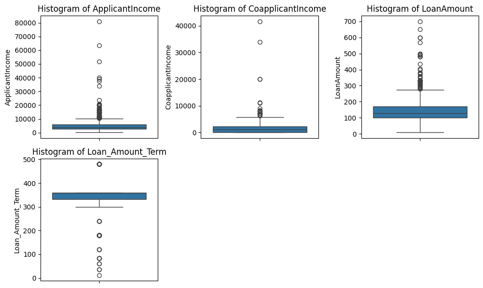

```python
visualize_outliers(loans)
```

**Applicant Income Distribution:**

The median applicant income sits at #3,813, indicating that half of the applicants earn less than this amount. However, the visualization reveals a wider range, with some applicants earning between #10,000 and #80,000. This suggests a potential income disparity among applicants.

**Loan Amount Distribution:**

The average loan amount is #149, as indicated by the mean value. However, the chart highlights the presence of outliers exceeding #300. These outliers seem to be valid data points and might represent applicants requiring larger loans. Since they are not errors, it's reasonable to keep them for further analysis.

### Descriptive statistics

```python
# Descriptive stats of loans
loans.describe()
```

|  | ApplicantIncome | CoapplicantIncome | LoanAmount | Loan_Amount_Term |
| --- | --- | --- | --- | --- |
| count | 602.000000 | 602.000000 | 602.000000 | 602.000000 |
| mean | 5422.194352 | 1612.981728 | 148.935216 | 333.039867 |
| std | 6159.336898 | 2948.005981 | 87.674053 | 64.223080 |
| min | 150.000000 | 0.000000 | 9.000000 | 12.000000 |
| 25% | 2877.500000 | 0.000000 | 100.000000 | 333.000000 |
| 50% | 3813.500000 | 1128.500000 | 128.000000 | 360.000000 |
| 75% | 5795.000000 | 2295.250000 | 170.000000 | 360.000000 |
| max | 81000.000000 | 41667.000000 | 700.000000 | 480.000000 |

### Exploratory Data Analysis

#### Univariate Analysis: Categorical columns

```python
# viewing only categorical
loans.select_dtypes(include='category').head()
```

| Loan_ID | Gender | Married | Dependents | Graduate | Self_Employed | Credit_History | Property_Area | Loan_Status |
| --- | --- | --- | --- | --- | --- | --- | --- | --- |
| 2284 | Male | Single | 0 | No | No | Yes | Rural | Y |
| 2287 | Female | Single | 0 | Yes | No | No | Semiurban | N |
| 2288 | Male | Married | 2 | No | No | No | Urban | N |
| 2296 | Male | Single | 0 | No | No | Yes | Rural | N |
| 2297 | Male | Single | 0 | Yes | No | Yes | Semiurban | Y |

```python
def plot_categorical_distributions(df):
  """
  Plots count plots for all categorical columns in a pandas DataFrame.

  Args:
      df (pandas.DataFrame): The DataFrame containing the data.
  """
  categorical_cols = df.select_dtypes(include='category').columns  # Select categorical columns
  rows = int(np.ceil(len(categorical_cols) / 2))  # Calculate number of rows for subplots
  cols = 2  # Number of columns for subplots (adjust as needed)
  fig, axes = plt.subplots(rows, cols, figsize=(15, rows * 7))  # Create subplots

  for i, col in enumerate(categorical_cols):
    row = int(i / cols)
    col_index = i % cols
    ax = axes[row, col_index]
    sns.countplot(data=df, x=col, hue=col, saturation=1, ax=ax)  # Plot on current subplot
    ax.set_title(f'Distribution of {col}', fontdict={'fontsize': 14, 'fontweight':'bold'})
    ax.set_xlabel(col, fontweight= 'bold')
    ax.set_ylabel('Frequency', fontweight= 'bold')
    ax.tick_params(bottom=False)  # Remove x-axis ticks for readability

  plt.tight_layout()
  plt.show()
```

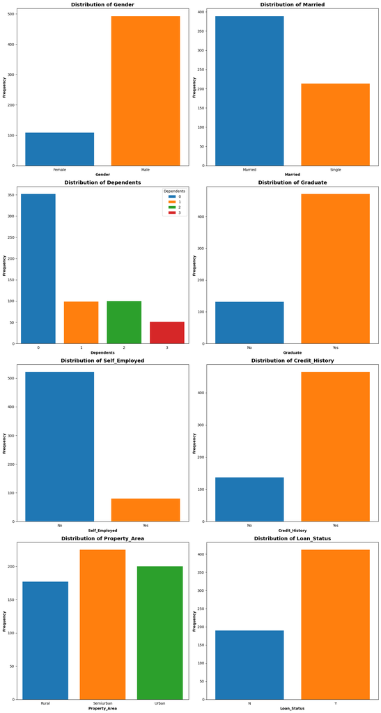

```python
plot_categorical_distributions(loans)
```

#### Univariate Analysis: Continuous variables

```python
loans.select_dtypes(include=['float64', 'int64']).head()
```

| Loan_ID | ApplicantIncome | CoapplicantIncome | LoanAmount | Loan_Amount_Term |
| --- | --- | --- | --- | --- |
| 2284 | 3902 | 1666 | 109 | 333 |
| 2287 | 1500 | 1800 | 103 | 333 |
| 2288 | 2889 | 0 | 45 | 180 |
| 2296 | 2755 | 0 | 65 | 300 |
| 2297 | 2500 | 20000 | 103 | 333 |

```python
def plot_continuous_histograms(df):
    """
    Plots histograms for all continuous columns in a DataFrame.

    Args:
        df (pandas.DataFrame): The input DataFrame.

    Returns:
        None
    """
    numeric_cols = df.select_dtypes(include=['float64', 'int64']).columns
    nrows = len(numeric_cols)
    ncols = 1
    fig, axes = plt.subplots(nrows=nrows, ncols=ncols, figsize=(7, 5 * nrows), sharey=False)

    if nrows == 1:
        axes = [axes]  # Make axes a list for consistent indexing

    for i, col in enumerate(numeric_cols):
        ax = axes[i]
        sns.histplot(data=df, x=col, ax=ax)
        ax.set_title(f'Distribution of {col}', fontdict={'fontweight': 'bold', 'fontsize': 13})
        ax.set_xlabel(col, fontweight='bold')
        ax.set_ylabel('Count', fontweight='bold')

    plt.tight_layout()
    plt.show()
```

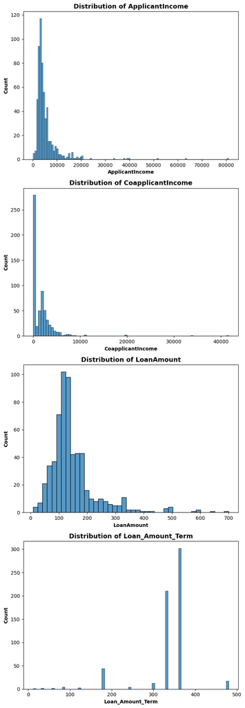

```python
plot_continuous_histograms(loans)
```

#### Bivariate Analysis

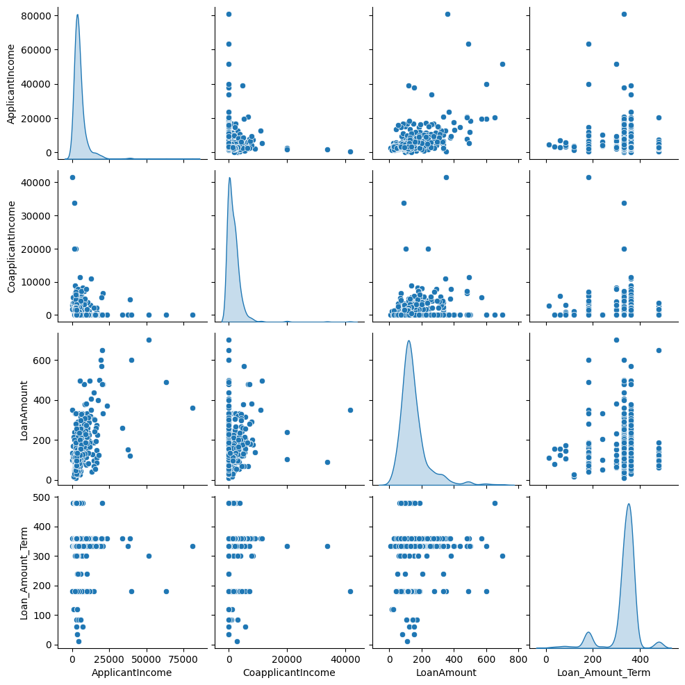

```python
sns.pairplot(loans, diag_kind='kde')
plt.show()
```

There seem to be a positive correlation between loan amount and an applicant's income.

### Required analyses

```python
# Descriptive analysis
print("\nTotal amount loaned by AFS: ", loans['LoanAmount'].sum())
print("Average amount loaned: ", round(loans['LoanAmount'].mean(),2))
print("Average loan term: ", loans['Loan_Amount_Term'].mean())
```

```
Total amount loaned by AFS:  89659
Average amount loaned:  148.94
Average loan term:  333.03986710963454
```

```python
# Applicant counts by approval status and gender, (Approved=Y , Rejected=N)
print("Applicant counts by approval status and gender:")
loans.groupby(['Loan_Status', 'Gender'], observed=True).size().unstack(fill_value=0)
```

```
Applicant counts by approval status and gender:
```

| Gender Loan_Status | Female | Male |
| --- | --- | --- |
| N | 37 | 153 |
| Y | 72 | 340 |

```python
# Gender distribution (Approved and Rejected)
gender_approved = loans[loans['Loan_Status'] == 'Y']['Gender'].value_counts()
gender_rejected = loans[loans['Loan_Status'] == 'N']['Gender'].value_counts()
```

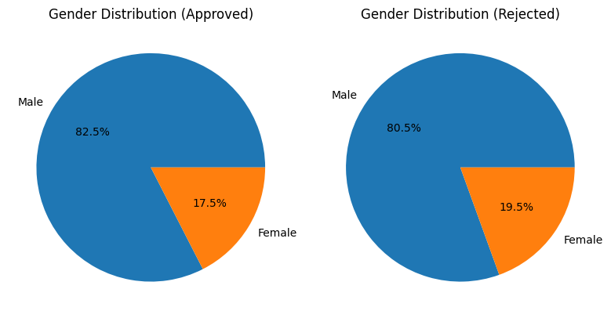

```python
# Distribution of gender for approved loan applicants
plt.figure(figsize=(8, 6))
plt.subplot(1, 2, 1)
plt.pie(gender_approved, labels=gender_approved.index, autopct='%1.1f%%')
plt.title('Gender Distribution (Approved)')

plt.subplot(1, 2, 2)
plt.pie(gender_rejected, labels=gender_rejected.index, autopct='%1.1f%%')
plt.title('Gender Distribution (Rejected)')
plt.tight_layout()

plt.show()
```

```python
# Applicant counts by approval status and gender
print("Applicant counts by approval status and gender:")
loans.groupby(['Loan_Status', 'Gender'], observed=True).size().unstack(fill_value=0)
```

```
Applicant counts by approval status and gender:
```

| Gender Loan_Status | Female | Male |
| --- | --- | --- |
| N | 37 | 153 |
| Y | 72 | 340 |

```python
# Maximum and minimum loan amounts
max_loan = loans['LoanAmount'].max()
min_loan = loans['LoanAmount'].min()

print(f"Maximum loan amount: {max_loan}")
print(f"Minimum loan amount: {min_loan}")
```

```
Maximum loan amount: 700
Minimum loan amount: 9
```

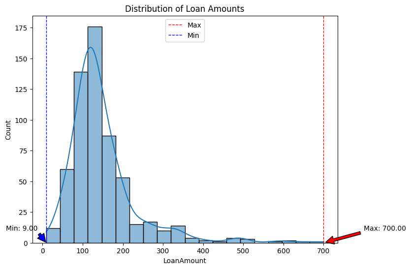

```python
plt.figure(figsize=(8, 6))
sns.histplot(loans['LoanAmount'], bins=20, kde=True)
plt.title('Distribution of Loan Amounts')

# Annotate maximum and minimum values
plt.annotate('Max: {:.2f}'.format(max_loan), xy=(max_loan, 0), xytext=(max_loan + 100, 10),
             arrowprops=dict(facecolor='red', shrink=0.05))
plt.annotate('Min: {:.2f}'.format(min_loan), xy=(min_loan, 0), xytext=(min_loan - 100, 10),
             arrowprops=dict(facecolor='blue', shrink=0.05))

# Draw vertical lines for max and min
plt.axvline(x=max_loan, color='red', linestyle='dashed', linewidth=1, label='Max')
plt.axvline(x=min_loan, color='blue', linestyle='dashed', linewidth=1, label='Min')
plt.legend()

plt.show()
```

```
Percentage of self-employed applicants with approved loans: 13.59%
```

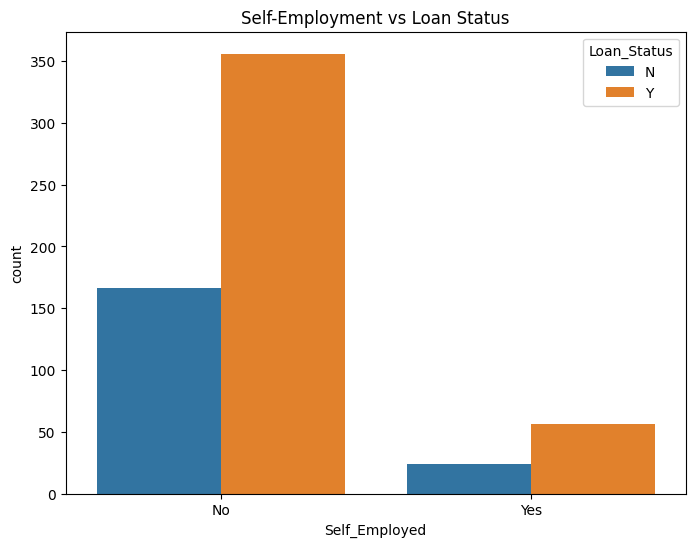

```python
# Percentage of self-employed with approved loans
self_employed_approved = loans[(loans['Self_Employed'] == 'Yes') & (loans['Loan_Status'] == 'Y')].shape[0]
total_approved = loans[loans['Loan_Status'] == 'Y'].shape[0]
self_employed_approved_percentage = (self_employed_approved / total_approved) * 100

print(f"Percentage of self-employed applicants with approved loans: {self_employed_approved_percentage:.2f}%")

plt.figure(figsize=(8, 6))
sns.countplot(x='Self_Employed', hue='Loan_Status', data=loans)
plt.title('Self-Employment vs Loan Status')
plt.show()
```

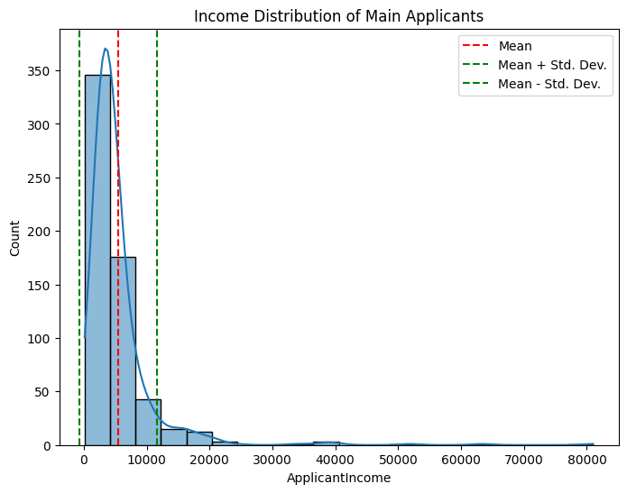

```
Mean income of main applicants: 5422.19
Standard deviation of income: 6159.34
```

```python
# Income distribution of  applicants
plt.figure(figsize=(8, 6))
sns.histplot(loans['ApplicantIncome'], bins=20, kde=True)
plt.title('Income Distribution of Main Applicants')
plt.axvline(loans['ApplicantIncome'].mean(), color='r', linestyle='--', label='Mean')
plt.axvline(loans['ApplicantIncome'].mean() + loans['ApplicantIncome'].std(), color='g', linestyle='--', label='Mean + Std. Dev.')
plt.axvline(loans['ApplicantIncome'].mean() - loans['ApplicantIncome'].std(), color='g', linestyle='--', label='Mean - Std. Dev.')
plt.legend()
plt.show()

print(f"\nMean income of main applicants: {loans['ApplicantIncome'].mean():.2f}")
print(f"Standard deviation of income: {loans['ApplicantIncome'].std():.2f}")
```

```python
# Top 10 applicants by loan amount
loans.sort_values(by='LoanAmount', ascending=False).head(10)
```

| Loan_ID | Gender | Married | Dependents | Graduate | Self_Employed | ApplicantIncome | CoapplicantIncome | LoanAmount | Loan_Amount_Term | Credit_History | Property_Area | Loan_Status |
| --- | --- | --- | --- | --- | --- | --- | --- | --- | --- | --- | --- | --- |
| 1585 | Male | Married | 3 | Yes | No | 51763 | 0 | 700 | 300 | Yes | Urban | Y |
| 1469 | Male | Single | 0 | Yes | Yes | 20166 | 0 | 650 | 480 | No | Urban | Y |
| 1536 | Male | Married | 3 | Yes | No | 39999 | 0 | 600 | 180 | No | Semiurban | Y |
| 2813 | Female | Married | 1 | Yes | Yes | 19484 | 0 | 600 | 333 | Yes | Semiurban | Y |
| 2191 | Male | Married | 0 | Yes | No | 19730 | 5266 | 570 | 360 | Yes | Rural | N |
| 2547 | Male | Married | 1 | Yes | No | 18333 | 0 | 500 | 333 | Yes | Urban | N |
| 2959 | Female | Married | 1 | Yes | No | 12000 | 0 | 496 | 333 | Yes | Semiurban | Y |
| 1610 | Male | Married | 3 | Yes | No | 5516 | 11300 | 495 | 360 | No | Semiurban | N |
| 2101 | Male | Married | 0 | Yes | No | 63337 | 0 | 490 | 180 | Yes | Urban | Y |
| 2693 | Male | Married | 2 | Yes | Yes | 7948 | 7166 | 480 | 333 | Yes | Rural | Y |

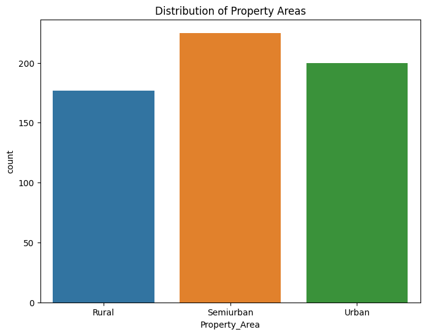

```python
# Property distribution of loan applicants
plt.figure(figsize=(8, 6))
sns.countplot(x='Property_Area', data=loans, hue='Property_Area')
plt.title('Distribution of Property Areas')
plt.show()
```